# Bayesian Modeling with RJAGS

## Libraries

```r
options(warn = -1)
library(ggplot2)
library(ggridges)
library(ggExtra)
library(dplyr)
library(rjags)
library(coda)
library(openintro)
library(mosaic)
```

## Simulating a Beta prior

Suppose you're running in an election for public office. Let $p$ be your underlying support, the proportion of voters that plan to vote for you. Based on past polls, your prior model of $p$ is captured by a Beta distribution with shape parameters $45$ and $55$.

We will approximate the $p \sim Beta(45, 55)$ prior using random samples from the `rbeta()` function.

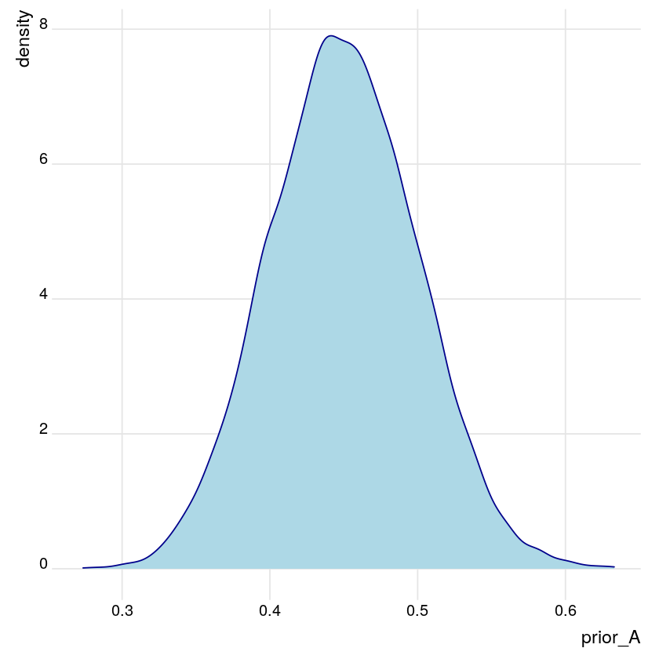

```r
# Sample 10000 draws from Beta(45,55) prior
prior_A <- rbeta(n = 10000, shape1 = 45, shape2 = 55)

# Store the results in a data frame
prior_sim <- data.frame(prior_A)

# Construct a density plot of the prior sample
ggplot(prior_sim, aes(x = prior_A)) + geom_density(color='darkblue', fill = 'lightblue') + theme_ridges()
```

## Comparing & contrasting Beta priors

The $Beta(a,b)$ distribution is defined on the interval from $0$ to $1$, thus provides a natural and flexible prior for your underlying election support, $p$. We can tune the Beta shape parameters $a$ and $b$ to produce alternative prior models. We will compare our original $Beta(45,55)$ prior with two alternatives: $Beta(1, 1)$ and $Beta(100, 100)$.

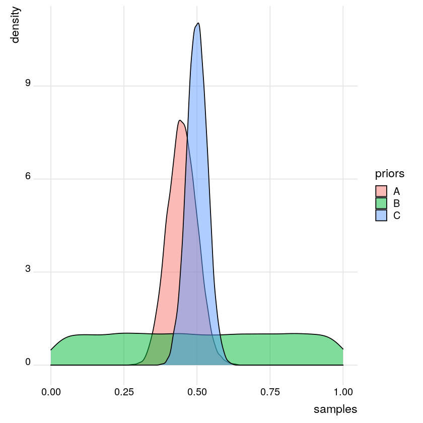

```r
# Sample 10000 draws from the Beta(1,1) prior
prior_B <- rbeta(n = 10000, shape1 = 1, shape2 = 1)

# Sample 10000 draws from the Beta(100,100) prior
prior_C <- rbeta(n = 10000, shape1 = 100, shape2 = 100)

# Combine the results in a single data frame
prior_sim <- data.frame(samples = c(prior_A, prior_B, prior_C),
        priors = rep(c("A","B","C"), each = 10000))

# Plot the 3 priors
ggplot(prior_sim, aes(x = samples, fill = priors)) + geom_density(alpha = 0.5) + theme_ridges()
```

Prior $B$ reflects *vague* prior information about $p$ - it gives equal prior weight to all values of $p$ between $0$ and $1$.

Prior $C$ reflects more prior certainty about $p$ - it has less spread and is centered around a mean that's greater than that for Prior $A$.

## Polling Data

- **parameter**
  - $p$ = proportion of voters that support you
- **data**
  - $X = 6$ of $n = 10$ or $60\%$ of polled voters plan to vote/support you
- **Insights**
  - You are more likely to have observed these data if $p \approx 0.6$ than if $p < 0.5$.

## Modeling the dependence of $X$ on $p$

- **Poll assumptions:**
- Voters are independent: $p$ = probability that a voter supports you
- $X$ = number of $n$ polled voters that support you (count of successes in $n$ independent trials, each having probability of success $p$)
- **Conditional distribution of $X$ given $p$:**

$$X \sim Bin(n, p)$$

## Likelihood

The likelihood function summarizes the likelihood of observing polling data $X$ under different values of the underlying support parameter $p$. It is a function of $p$. Thus the likelihood is a function of $p$ that depends on the observed data $X$, in turn it provides insight into which parameter values are most compatible with the poll.

- high likelihood $\Rightarrow p$ is compatible with the data
- low likelihood $\Rightarrow p$ is not compatible with the data

# Simulating the dependence of $X$ on $p$

In your quest for election to public office, your campaign polls $10$ likely voters. Let $X$ be the number that support you. Of course, $X$ varies from sample to sample and depends upon $p$, your underlying support in the broader population. Since $X$ is a count of successes in $10$ independent trials, each having probability of success $p$, we can model its dependence on $p$ by the Binomial distribution: $Bin(10, p)$.

We will simulate the Binomial model using random samples from the `rbinom(n, size, prob)` function. This *vectorized* function draws $n$ samples from a $Bin(size, prob)$ distribution. Given a vector of prob values, the first prob value will be used for the first draw, the second prob value will be used for the second draw, etc.

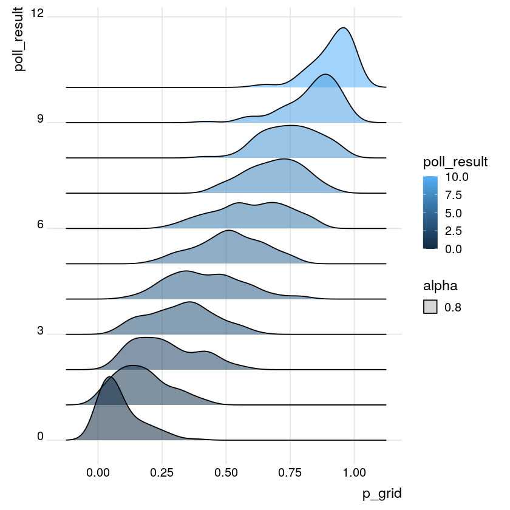

```r
# Define a vector of 1000 p values from 0 to 1
p_grid <- seq(from = 0, to = 1, length.out = 1000)

# Simulate 1 poll result for each p in p_grid
poll_result <- rbinom(n = 1000, # Number of simulations
                      size = 10, # Number of Trials (voters)
                      prob = p_grid) # Underlying proportion of success between 0.0 and 1.0

# Create likelihood_sim data frame
likelihood_sim <- data.frame(p_grid, poll_result)

# Density plots of p_grid grouped by poll_result
ggplot(likelihood_sim, aes(x = p_grid, y = poll_result, group = poll_result, fill = poll_result, alpha = 0.8)) +
geom_density_ridges() + theme_ridges()
```

Notice that polls in which $0$ people supported you `(poll_result = 0)` correspond to smaller values of underlying support $p$ `(p_grid)`. The opposite is true for polls in which all $10$ people supported you.

## Approximating the likelihood function

The first election poll is in! $X = 6$ of $10$ polled voters plan to vote for you. You can use these data to build insight into your underlying support $p$. To this end, we will use the `likelihood_sim` data frame. This contains the values of $X$ `(poll_result)` simulated from each of $1,000$ possible values of $p$ between $0$ to $1$ `(p_grid)`.

Here we supply a fill condition in order to highlight the distribution which corresponds to our observed `poll_result`, $X=6$. This provides insight into which values of $p$ are the most compatible with our observed poll data.

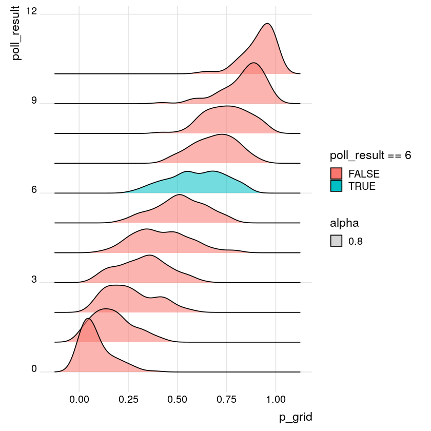

```r
# Density plots of p_grid grouped by poll_result
ggplot(likelihood_sim, aes(x = p_grid, y = poll_result, group = poll_result, fill = poll_result == 6, alpha = 0.8)) +
geom_density_ridges() + theme_ridges()
```

# Posterior model of $p$

- **Prior:** $p \sim Beta(45, 55)$
- **likelihood:** $X \sim Bin(10, p)$
- **Bayes' Rule:** posterior $\propto$ prior $\times$ likelihood

# Getting Started with RJAGS

**Bayesian Models in RJAGS: DEFINE**

- $X \sim Bin(n, p)$
- $p \sim Beta(a, b)$

## Define, compile, and simulate

In your election quest, let $p$ be the proportion of the underlying voting population that supports you. Built from previous polls & election data, your prior model of $p$ is a $Beta(a,b)$ with shape parameters $a=45$ and $b=55$. For added insight into $p$, you also polled $n$ potential voters. The dependence of $X$, the number of these voters that support you, on $p$ is modeled by the $Bin(n,p)$ distribution.

In the completed poll, $X=6$ of $n=10$ voters supported you. The next goal is to update the model of $p$ in light of these observed polling data. To this end, we will use the `rjags` package to approximate the posterior model of $p$. We break this down into the $3$ `rjags` steps: *define, compile, simulate.*

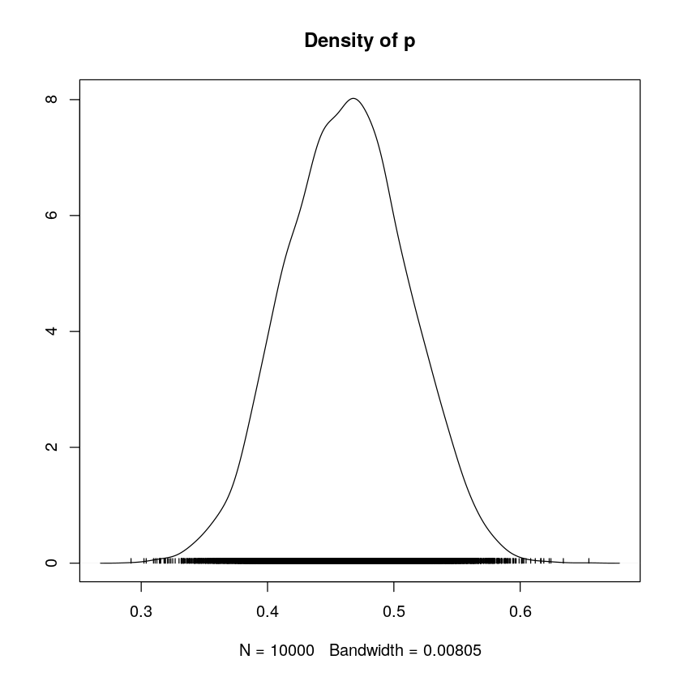

```r
# DEFINE the model
vote_model <- "model{
    # Likelihood model for X
    X ~ dbin(p, n)

    # Prior model for p
    p ~ dbeta(a, b)
}"

# COMPILE the model
vote_jags <- jags.model(textConnection(vote_model),
    data = list(a = 45, b = 55, X = 6, n = 10),
    inits = list(.RNG.name = "base::Wichmann-Hill", .RNG.seed = 100))

# SIMULATE the posterior
vote_sim <- coda.samples(model = vote_jags, variable.names = c("p"), n.iter = 10000)

# PLOT the posterior
plot(vote_sim, trace = FALSE)
```

Notice that after observing a poll in which $6$ of $10$ ($60\%$) of voters supported you, your updated posterior optimism and certainty about your underlying support, $p$, are slightly higher than they were prior to the poll.

# Updating the posterior

The posterior model of your underlying election support $p$ is informed by both the prior model of $p$ and polling data $X$. The code below reminds us of the posterior that evolved from the original prior ($Beta(45, 55)$) and original poll data ($X=6$ of $n=10$ polled voters support you).

In a 3-steps we will explore how using a different prior model or observing new data (or a combination of the two) might impact the posterior.

## ($X=6$, $n=10$)

Here we re-compile, simulate, and plot the $p$ posterior to reflect the setting in which we start with a $Beta(1,1)$ prior but observe the same polling data ($X=6$, $n=10$). NOTE: Recall that $Beta(1,1)$ is uniform across the $(0,1)$ interval.

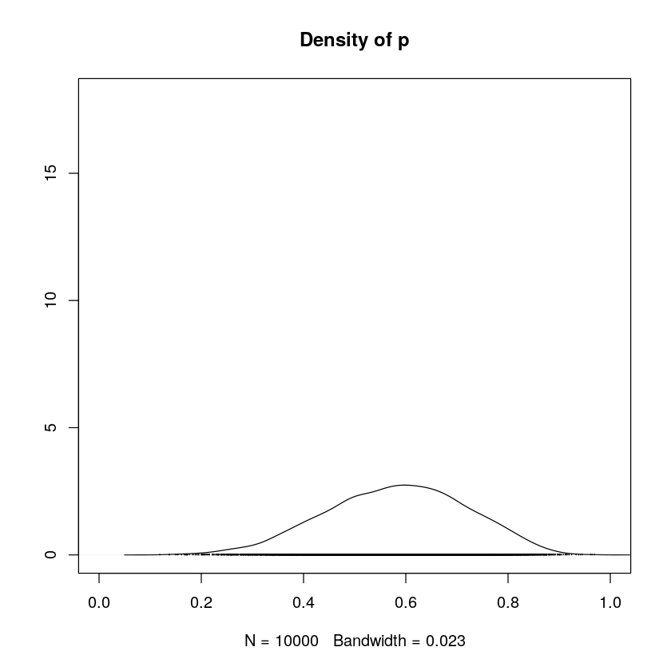

```r
# COMPILE the model
vote_jags <- jags.model(textConnection(vote_model),
    data = list(a = 1, b = 1, X = 6, n = 10),
    inits = list(.RNG.name = "base::Wichmann-Hill", .RNG.seed = 100))

# SIMULATE the posterior
vote_sim <- coda.samples(model = vote_jags, variable.names = c("p"), n.iter = 10000)

# PLOT the posterior
plot(vote_sim, trace = FALSE, xlim = c(0,1), ylim = c(0,18))
```

## ($X=220$, $n=400$)

In a new poll, $214$ of $390$ voters support you. Combined with the first poll, a total $X=220$ of $n=400$ voters support you. We Re-compile, simulate, and plot the $p$ posterior to reflect these combined poll results and a $Beta(1,1)$ prior.

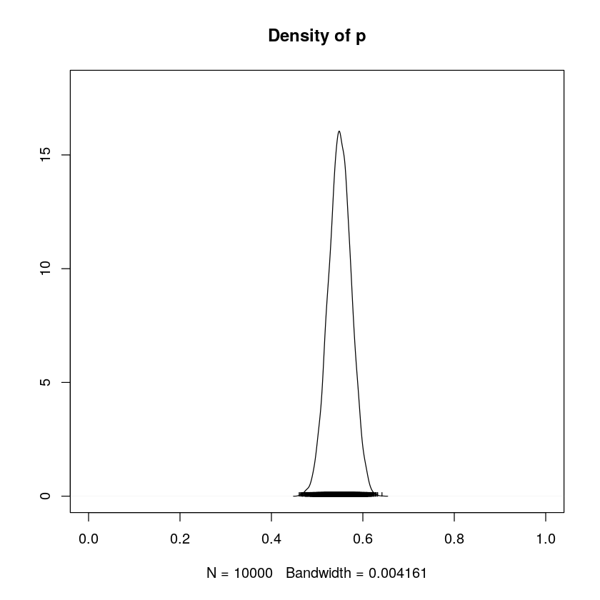

```r
# COMPILE the model
vote_jags <- jags.model(textConnection(vote_model),
    data = list(a = 1, b = 1, X = 220, n = 400),
    inits = list(.RNG.name = "base::Wichmann-Hill", .RNG.seed = 100))

# SIMULATE the posterior
vote_sim <- coda.samples(model = vote_jags, variable.names = c("p"), n.iter = 10000)

# PLOT the posterior
plot(vote_sim, trace = FALSE, xlim = c(0,1), ylim = c(0,18))
```

## ($Beta(45,55)$) prior

Finally we, re-compile, simulate, and plot the $p$ posterior to reflect the combined poll results ($X=220$ of $n=400$) and our original $Beta(45,55)$ prior.

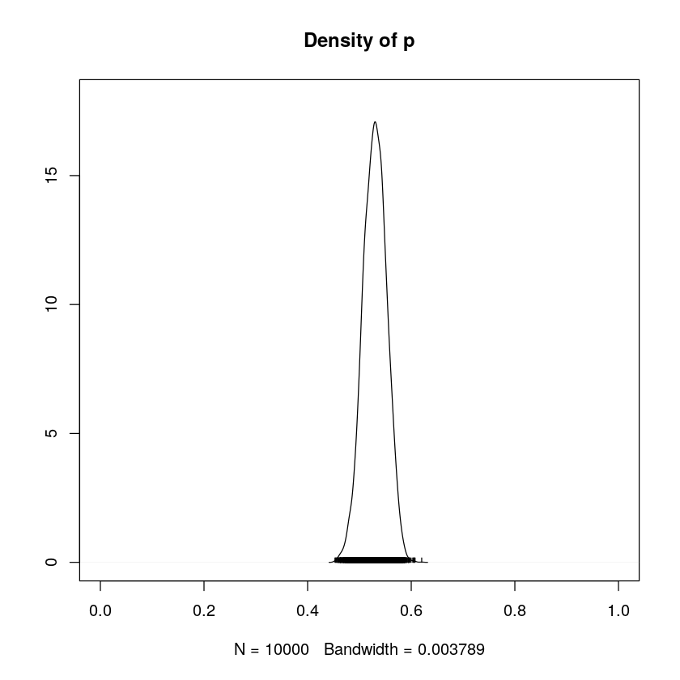

```r
# COMPILE the model
vote_jags <- jags.model(textConnection(vote_model),
    data = list(a = 45, b = 55, X = 220, n = 400),
    inits = list(.RNG.name = "base::Wichmann-Hill", .RNG.seed = 100))

# SIMULATE the posterior
vote_sim <- coda.samples(model = vote_jags, variable.names = c("p"), n.iter = 10000)

# PLOT the posterior
plot(vote_sim, trace = FALSE, xlim = c(0,1), ylim = c(0,18))
```

- Even in light of the same data, different priors lead to different posteriors.
- The influence of the prior on the posterior diminishes as the sample size of your data increases.
- As sample size increases, your posterior understanding becomes more precise.

# The Normal-Normal Model

## Sleep deprivation

**Research Question:**

- How does sleep deprivation impact reaction time?

**The Study**

- measure reaction time on Day $0$
- restrict sleep to $3$ hours per night
- measure reaction time on Day $3$
- measure the change in reaction time

### Modeling change in reaction time

$Y_i$ = change in reaction time (ms)

**Assume**

- $Y_i$ are Normally distributed around some average change in reaction time $m$ with standard deviation $s$.

$$Y_i \sim N (m, s^2 )$$

#### Prior model for parameter $m$

- $Y_i$ = change in reaction time (ms)
- $Y_i \sim N (m, s^2 )$
- $m$ = average $Y_i$

**Prior information:**

#### Prior model for parameter $s$

- $Y_i$ = change in reaction time (ms)
- $Y_i \sim N(m, s^2 )$
- $s$ = standard deviation of $Y_i$

**Prior information:**

- $s > 0$
- With *normal* sleep, s.d. in reaction times is $\sim 30$ ms
- $s$ is equally likely to be anywhere from $0$ to $200$ ms

##### The Normal-Normal Model

**Likelihood:**

- $Y_i \sim N(m, s^2 )$

**Priors:**

- $m \sim N(50, 25^2 )$
- $s \sim Unif(0, 200)$

# Normal-Normal priors

Researchers developed a test to evaluate the impact of sleep deprivation on reaction time. For subject $i$, let $Y_i$ be the change in reaction time (in ms) after $3$ sleep deprived nights. Of course, people react differently to sleep deprivation. It's reasonable to assume that $Y_i$ are Normally distributed around some average $m$ with standard deviation $s$: $Y_i \sim N(m,s^2)$.

In the first step of our Bayesian analysis, we'll simulate the following prior models for parameters $m$ and $s$: $m \sim N(50,252)$ and $s \sim Unif(0,200)$.

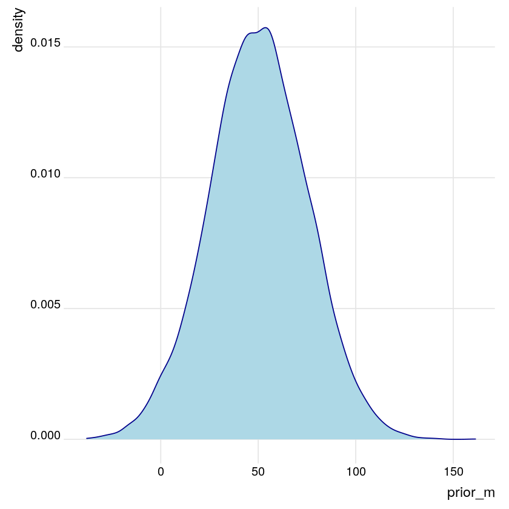

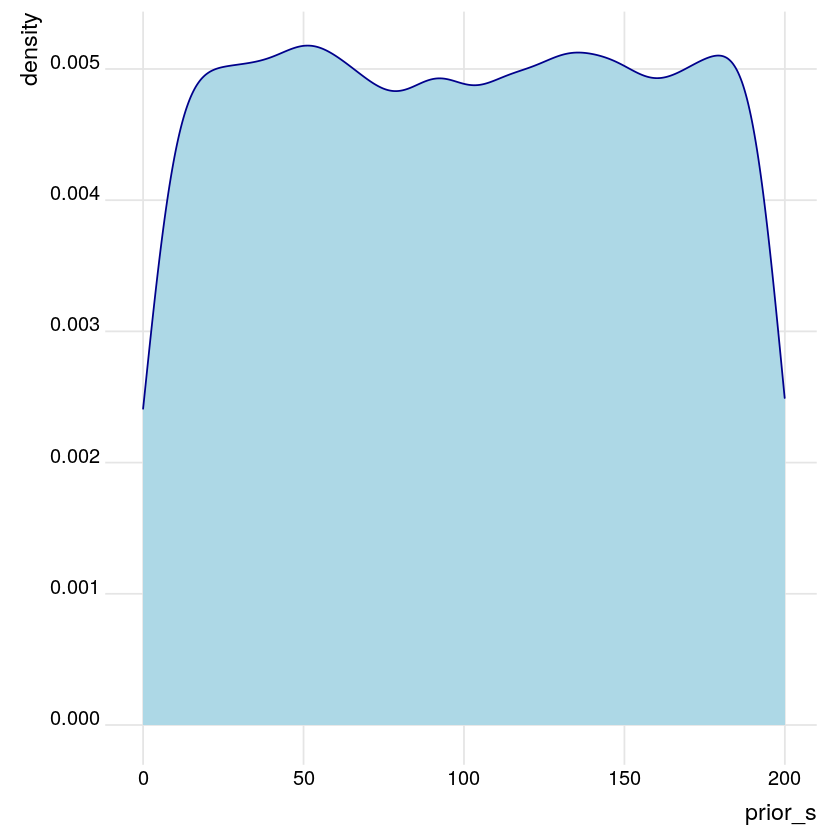

```r
# Take 10000 samples from the m prior
prior_m <- rnorm(n = 10000, mean = 50, sd = 25)

# Take 10000 samples from the s prior
prior_s <- runif(n = 10000, min = 0, max = 200)

# Store samples in a data frame
samples <- data.frame(prior_m, prior_s)

# Density plots of the prior_m & prior_s samples
#par(mfcol = c(2, 1))
ggplot(samples, aes(x = prior_m)) +
    geom_density(color='darkblue', fill = 'lightblue') + theme_ridges()
ggplot(samples, aes(x = prior_s)) +
    geom_density(color='darkblue', fill = 'lightblue') + theme_ridges()
```

# Sleep study data

Researchers enrolled $18$ subjects in a sleep deprivation study. Their observed sleep study data are loaded in the DataFrame `sleep_study`. These data contain the `day_0` reaction times and `day_3` reaction times after $3$ sleep deprived nights for each subject.

We will define and explore `diff_3`, the observed difference in reaction times for each subject.

A data.frame: 6 × 3

|  | subject <int> | day_0 <dbl> | day_3 <dbl> |
| --- | --- | --- | --- |
| 1 | 308 | 249.5600 | 321.4398 |
| 2 | 309 | 222.7339 | 204.7070 |
| 3 | 310 | 199.0539 | 232.8416 |
| 4 | 330 | 321.5426 | 285.1330 |
| 5 | 331 | 287.6079 | 320.1153 |
| 6 | 332 | 234.8606 | 309.7688 |

A data.frame: 1 × 2

| mean(diff_3) <dbl> | sd(diff_3) <dbl> |
| --- | --- |
| 26.34021 | 37.20764 |

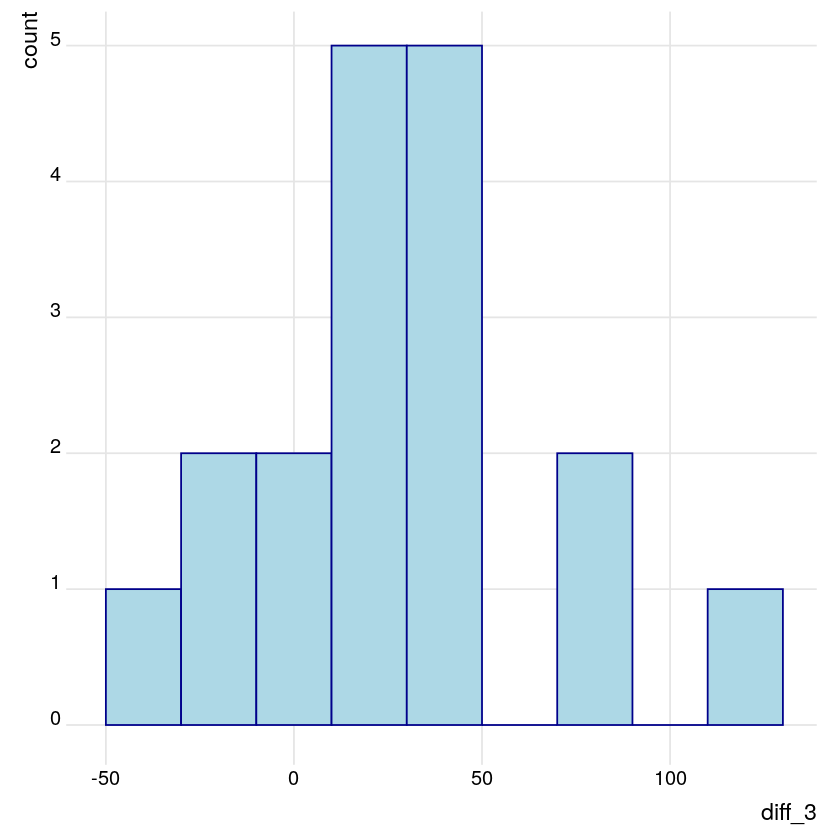

```r
# Check out the first 6 rows of sleep_study
sleep_study <- read.csv('https://assets.datacamp.com/production/repositories/2096/datasets/62737a3d23519405d7bfe3eceb85be0f97a07862/sleep_study.csv',
                        header = TRUE)
head(sleep_study)

# Define diff_3
sleep_study <- sleep_study %>%
    mutate(diff_3 = day_3 - day_0)

# Histogram of diff_3
ggplot(sleep_study, aes(x = diff_3)) +
    geom_histogram(binwidth = 20, color='darkblue', fill = 'lightblue') + theme_ridges()

# Mean and standard deviation of diff_3
sleep_study %>%
    summarize(mean(diff_3), sd(diff_3))
```

Reaction times increased by an average of $\sim 26$ ms with a standard deviation of $\sim 37$ ms. Further, only $4$ of the $18$ test subjects had faster reaction times on day $3$ than on day $0$.

## DEFINE the Normal-Normal for RJAGS

- $Y_i \sim N(m, s^2 )$ for $i$ in $1, 2, \dots , 18$
- **NOTE:** precision = $variance^{−1}$ = $s^{−2}$
- $m \sim N(50, 25^2)$
- $s \sim Unif(0, 200)$

## Define, compile, & simulate the Normal-Normal

Upon observing the change in reaction time $Y_i$ for each of the $18$ subjects $i$ enrolled in the sleep study, WE can update our posterior model of the effect of sleep deprivation on reaction time. This requires the combination of insight from the *likelihood* and *prior* models:

- **likelihood:** $Y_i \sim N(m,s^2)$
- **Priors:** $m \sim N(50,252)$ and $s \sim Unif(0,200)$

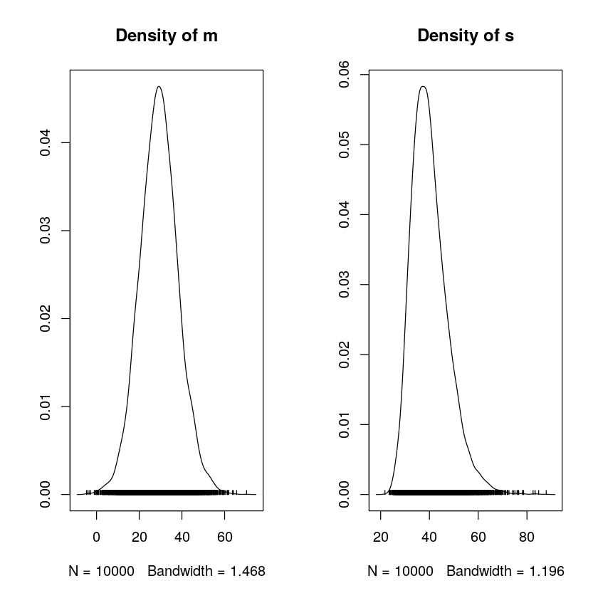

```r
# DEFINE the model
sleep_model <- "model{
    # Likelihood model for Y[i]
    for(i in 1:length(Y)) {
        Y[i] ~ dnorm(m, s^(-2))
    }

    # Prior models for m and s
    m ~ dnorm(50, 25^(-2))
    s ~ dunif(0, 200)
}"

# COMPILE the model
sleep_jags <- jags.model(
  textConnection(sleep_model),
  data = list(Y = sleep_study$diff_3),
  inits = list(.RNG.name = "base::Wichmann-Hill", .RNG.seed = 1989)
)

# SIMULATE the posterior
sleep_sim <- coda.samples(model = sleep_jags, variable.names = c("m", "s"), n.iter = 10000)

# PLOT the posterior
plot(sleep_sim, trace = FALSE)
```

We're more certain that average reaction time increases but that the magnitude of the increase is less than assumed prior to observing the data.

# Markov chains

Markov chains are stochastic models that describe sequences of possible events. Each event comes from a set of outcomes, and each outcome determines which outcome occurs next, according to a fixed set of probabilities. An important feature of Markov chains is that they are **memoryless:** everything that you would possibly need to predict the next event is available in the current state, and no new information comes from knowing historical events.

- **RJAGS goal:** Utilize Markov chains to approximate posteriors that are otherwise too complicated to define or sample
- The $m$ Markov chain traverses the sample space of $m$, mimics a random sample, and converges to the posterior.

## Storing Markov chains

Let $m$ be the average change in reaction time after $3$ days of sleep deprivation. Previously we obtained an approximated a sample of $10,000$ draws from the posterior model of $m$. We stored the resulting mcmc.list object as `sleep_sim`. The sample of $m$ values in `sleep_sim` is a dependent **Markov chain**, the distribution of which converges to the posterior.

```r
# Check out the head of sleep_sim
head(sleep_sim)

# Store the chains in a data frame
sleep_chains <- data.frame(sleep_sim[[1]], iter = 1:10000)

# Check out the head of sleep_chains
head(sleep_chains)
```

```
[[1]]
Markov Chain Monte Carlo (MCMC) output:
Start = 1001
End = 1007
Thinning interval = 1
            m        s
[1,] 17.25796 31.46256
[2,] 34.58469 37.88655
[3,] 36.45480 39.58056
[4,] 25.00971 39.69494
[5,] 29.95475 35.90001
[6,] 28.43894 37.46466
[7,] 38.32427 35.44081

attr(,"class")
[1] "mcmc.list"
```

A data.frame: 6 × 3

|  | m <dbl> | s <dbl> | iter <int> |
| --- | --- | --- | --- |
| 1 | 17.25796 | 31.46256 | 1 |
| 2 | 34.58469 | 37.88655 | 2 |
| 3 | 36.45480 | 39.58056 | 3 |
| 4 | 25.00971 | 39.69494 | 4 |
| 5 | 29.95475 | 35.90001 | 5 |
| 6 | 28.43894 | 37.46466 | 6 |

## Markov chain trace plots

A trace plot provides a visualization of a Markov chain's longitudinal behavior. Specifically, a trace plot for the $m$ chain plots the observed chain value (y-axis) against the corresponding iteration number (x-axis).We will construct trace plots of the $m$ chain.

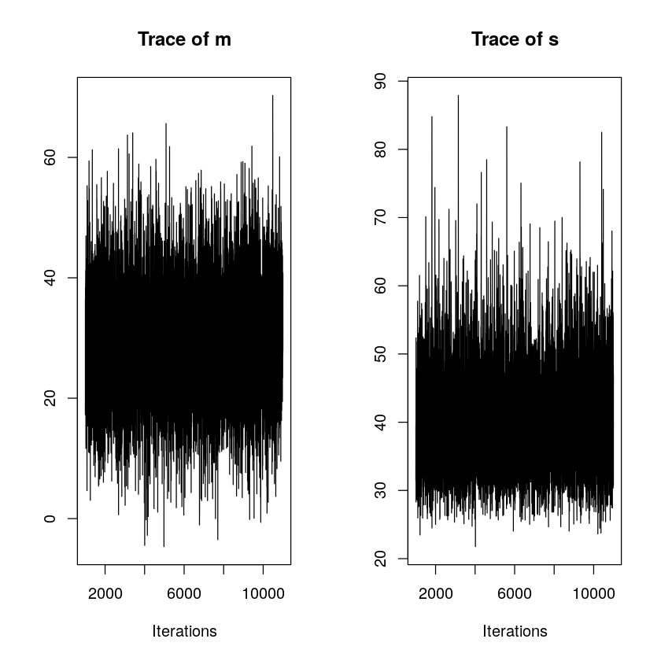

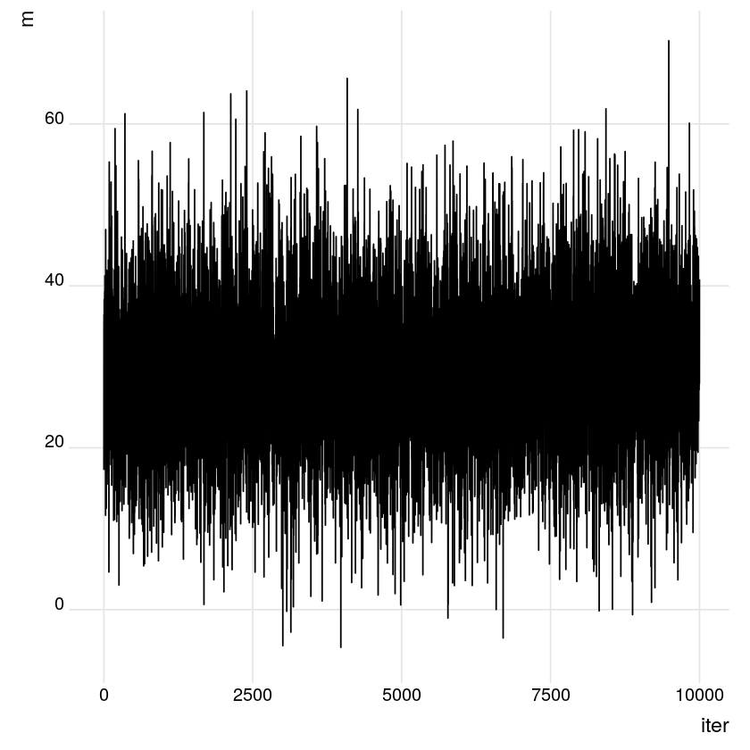

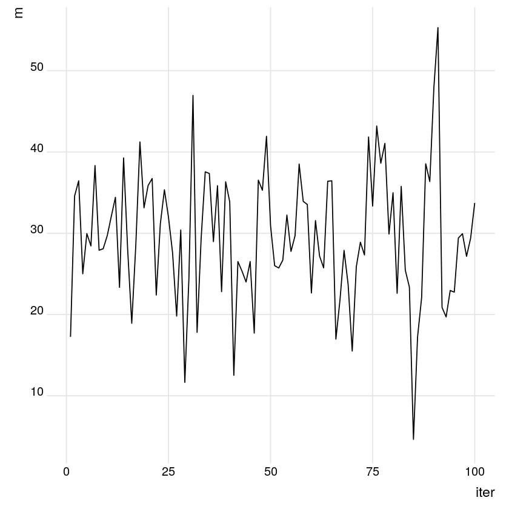

```r
# Use plot() to construct trace plots of the m and s chains
plot(sleep_sim, density = FALSE)

# Use ggplot() to construct a trace plot of the m chain
ggplot(sleep_chains, aes(x = iter, y = m)) +
    geom_line() + theme_ridges()

# Trace plot the first 100 iterations of the m chain
ggplot(sleep_chains[1:100, ], aes(x = iter, y = m)) +
    geom_line() + theme_ridges()
```

Note that the longitudinal behavior of the chain appears quite random and that the trend remains relatively constant. This is a good thing - it indicates that the Markov chain (likely) converges quickly to the posterior distribution of $m$.

## Markov chain density plots

Whereas a trace plot captures a Markov chain's longitudinal behavior, a density plot illustrates the final distribution of the chain values. In turn, the density plot provides an approximation of the posterior model. We will construct and examine density plots of the $m$ Markov chain.

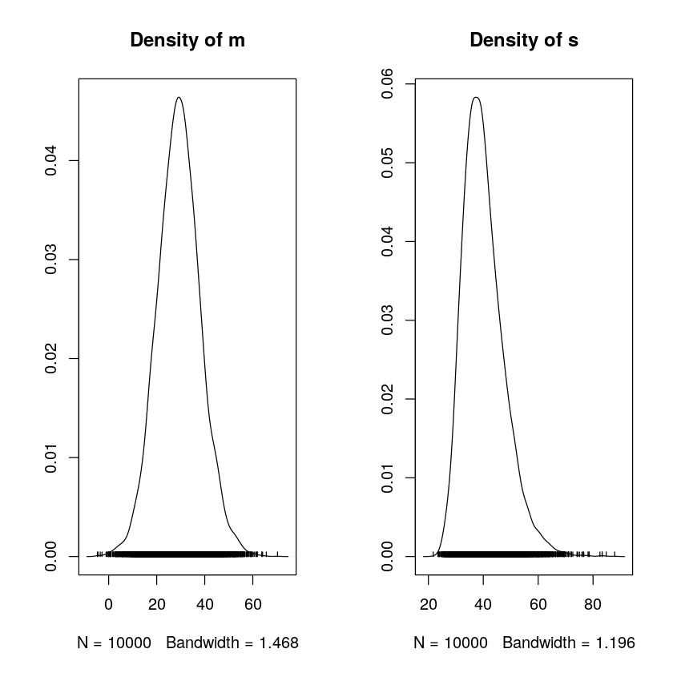

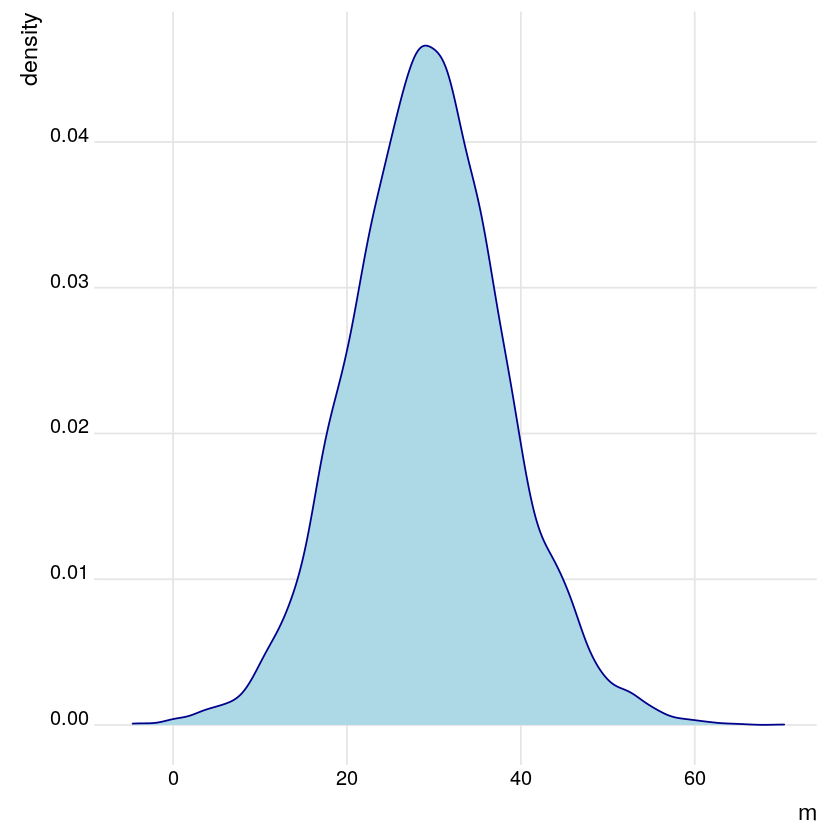

```r
# Use plot() to construct density plots of the m and s chains
plot(sleep_sim, trace = FALSE)

# Use ggplot() to construct a density plot of the m chain
ggplot(sleep_chains, aes(x = m)) +
    geom_density(color='darkblue', fill = 'lightblue') + theme_ridges()
```

These density plots approximate the posterior models of $m$ and $s$.

# Markov chain diagnostics & reproducibility

**A Good Markov Chain:**

- Stable and **constant variance**
- Stable and **constant trend**
- Correct by increasing number of iterations

**Reproducibility:**

- Set the RNG parameters **name** and **seed** for model reproducibility

**Examine the following diagnostics:**

- trace plots
- multiple chain output
- standard errors: **(naive) standard error**

$$ \sigma \div \sqrt{\text{number of iterations}}$$

## Multiple chains

Trace plots help us diagnose the quality of a Markov chain simulation. A "good" Markov chain will exhibit stability as the chain length increases and consistency across repeated simulations, or multiple chains. We will use **RJAGS** to run and construct trace plots for four parallel chains.

```
[[1]]
Markov Chain Monte Carlo (MCMC) output:
Start = 1001
End = 1007
Thinning interval = 1
            m        s
[1,] 26.95139 37.84838
[2,] 36.64104 36.26695
[3,] 24.85847 35.90455
[4,] 11.71905 42.25510
[5,] 18.31079 34.33902
[6,] 32.46486 36.35246
[7,] 47.61596 45.98280

[[2]]
Markov Chain Monte Carlo (MCMC) output:
Start = 1001
End = 1007
Thinning interval = 1
            m        s
[1,] 25.45950 44.70539
[2,] 31.44026 30.26747
[3,] 28.71086 30.02559
[4,] 44.18226 39.92576
[5,] 19.59408 39.10502
[6,] 22.76513 48.27164
[7,] 16.02904 42.43653

[[3]]
Markov Chain Monte Carlo (MCMC) output:
Start = 1001
End = 1007
Thinning interval = 1
            m        s
[1,] 25.03641 37.39892
[2,] 26.60073 37.03494
[3,] 41.09780 40.73958
[4,] 28.80065 40.52714
[5,] 27.98351 59.43210
[6,] 35.94824 31.57825
[7,] 29.31679 38.40879

[[4]]
Markov Chain Monte Carlo (MCMC) output:
Start = 1001
End = 1007
Thinning interval = 1
            m        s
[1,] 30.68009 60.92986
[2,] 28.51053 36.47619
[3,] 21.78438 29.11053
[4,] 27.70521 50.98422
[5,] 24.45239 46.24919
[6,] 40.56091 36.64938
[7,] 33.67518 34.38174

attr(,"class")
[1] "mcmc.list"
```

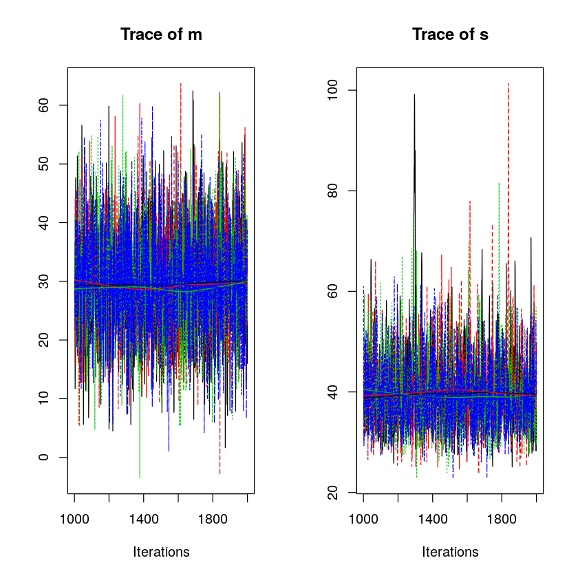

```r
# COMPILE the model
sleep_jags_multi <- jags.model(textConnection(sleep_model), data = list(Y = sleep_study$diff_3), n.chains = 4)

# SIMULATE the posterior
sleep_sim_multi <- coda.samples(model = sleep_jags_multi, variable.names = c("m", "s"), n.iter = 1000)

# Check out the head of sleep_sim_multi
head(sleep_sim_multi)

# Construct trace plots of the m and s chains
plot(sleep_sim_multi, density = FALSE)
```

The most important thing to notice here is the similarity and stability among the 4 parallel chains. This provides some reassurance about the quality and consistency of our Markov chain simulation.

## Naive standard errors

The mean of the $m$ Markov chain provides an estimate of the posterior mean of $m$. The naive standard error provides a measure of the potential error in this estimate. In turn, we can use this measure to determine an appropriate chain length. For example, suppose your goal is to estimate the posterior mean of $m$ within a standard error of $0.1$ ms. If your observed naive standard error exceeds this target, no problem! Simply run a longer chain - the error in using a Markov chain to approximate a posterior tends to decrease as chain length increases.

```r
# SIMULATE the posterior
sleep_sim_1 <- coda.samples(model = sleep_jags, variable.names = c("m", "s"), n.iter = 1000)

# Summarize the m and s chains of sleep_sim_1
summary(sleep_sim_1)

# RE-SIMULATE the posterior
sleep_sim_2 <- coda.samples(model = sleep_jags, variable.names = c("m", "s"), n.iter = 10000)

# Summarize the m and s chains of sleep_sim_2
summary(sleep_sim_2)
```

```
Iterations = 11001:12000
Thinning interval = 1
Number of chains = 1
Sample size per chain = 1000

1. Empirical mean and standard deviation for each variable,
   plus standard error of the mean:

   Mean    SD Naive SE Time-series SE
m 29.55 9.032   0.2856         0.2856
s 40.81 7.654   0.2420         0.3414

2. Quantiles for each variable:

   2.5%   25%   50%   75% 97.5%
m 12.00 23.62 29.31 35.58 47.48
s 28.34 35.25 39.97 45.41 58.60
```

```
Iterations = 12001:22000
Thinning interval = 1
Number of chains = 1
Sample size per chain = 10000

1. Empirical mean and standard deviation for each variable,
   plus standard error of the mean:

   Mean    SD Naive SE Time-series SE
m 29.33 9.080  0.09080         0.0942
s 40.12 7.483  0.07483         0.1115

2. Quantiles for each variable:

   2.5%   25%   50%   75% 97.5%
m 11.69 23.25 29.25 35.24 47.55
s 28.61 34.89 39.07 44.25 57.82
```

## Reproducibility

Now that we've completed some Markov chain diagnostics, we're ready to finalize our **RJAGS** simulation. To this end, reproducibility is crucial. To obtain reproducible simulation output, we must set the **seed** of the **RJAGS** random number generator. This works differently than in base **R**.

```r
# COMPILE the model
sleep_jags <- jags.model(textConnection(sleep_model), data = list(Y = sleep_study$diff_3),
                         inits = list(.RNG.name = "base::Wichmann-Hill", .RNG.seed = 1989))

# SIMULATE the posterior
sleep_sim <- coda.samples(model = sleep_jags, variable.names = c("m", "s"), n.iter = 10000)

# Summarize the m and s chains of sleep_sim
summary(sleep_sim)
```

```
Iterations = 1001:11000
Thinning interval = 1
Number of chains = 1
Sample size per chain = 10000

1. Empirical mean and standard deviation for each variable,
   plus standard error of the mean:

   Mean    SD Naive SE Time-series SE
m 29.29 8.980  0.08980        0.08854
s 40.19 7.519  0.07519        0.11557

2. Quantiles for each variable:

   2.5%   25%   50%   75% 97.5%
m 11.78 23.34 29.16 35.05 47.45
s 28.68 34.85 39.12 44.39 57.79
```

# A simple Bayesian regression model

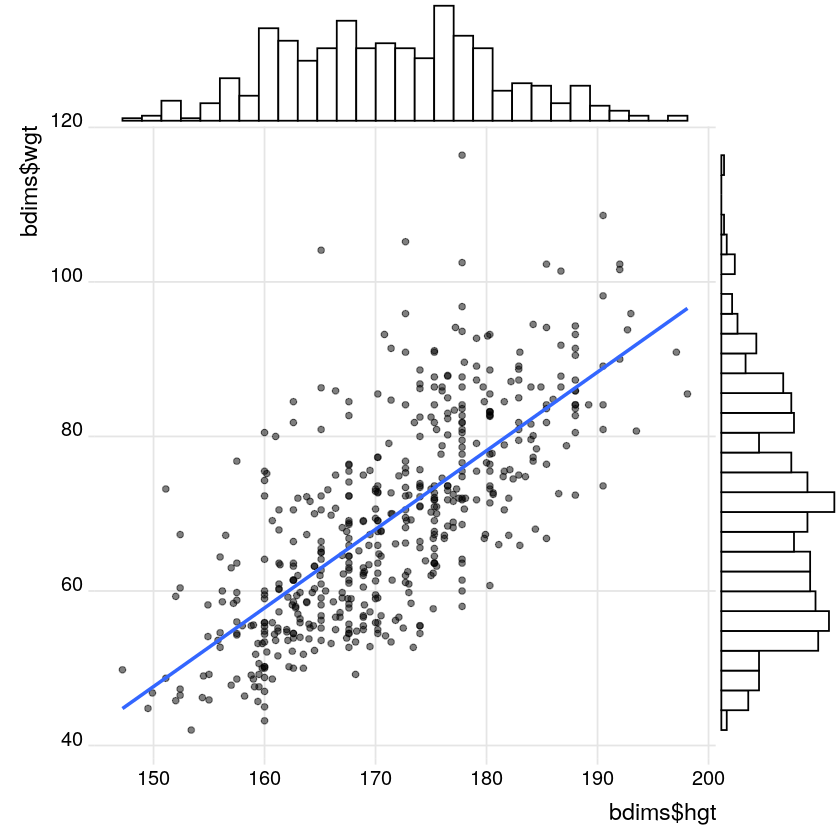

```r
data(bdims)

p = ggplot(bdims, aes(bdims$hgt, bdims$wgt)) +
geom_point(alpha=0.5) +
geom_smooth(method = "lm", se = FALSE) +
theme_ridges()
ggMarginal(p, type = "histogram", fill='white')
```

# Modeling weight by height

- $Y_i$ = weight of adult $i$ (kg)
- $X_i$ = height of adult $i$ (cm)

**Model:**

- $Y_i \sim N(m_i , s^2 )$
- $m_i = a + bX_i$

## Bayesian regression model

- $Y_i \sim N(m_i , s^2 )$
- $m_i = a + bX_i$
- $a = y-\text{intercept}$
  - Value of $m_i$ when $X_i = 0$
- $b$ = slope
  - Rate of change in weight (kg) per $1$ cm increase in height
- $s$ = residual standard deviation
  - Individual deviation from trend $m_i$

### Mathematical notation

- $Y_i \sim N(m_i , s^2 )$
- $m_i = a + bX_i$
- $a \sim N(0, 200^2)$
- $b \sim N(1, 0.5^2)$
- $s \sim Unif(0, 20)$

# Regression priors

Let $Y_i$ be the weight (in kg) of subject $i$. Past studies have shown that weight is linearly related to height $X_i$ (in cm). The average weight $m_i$ among adults of any shared height $X_i$ can be written as $m_i = a + b X_i$. But height isn't a perfect predictor of weight - individuals vary from the trend. To this end, it's reasonable to assume that $Y_i$ are Normally distributed around $m_i$ with residual standard deviation $s$: $Y_i \sim N(m_i, s^2)$.

Note the 3 parameters in the model of weight by height: intercept $a$, slope $b$, & standard deviation $s$. In the first step of our Bayesian analysis, we will simulate the following prior models for these parameters: $a \sim N(0, 200^2)$, $b \sim N(1, 0.5^2)$, and $s \sim Unif(0, 20)$.

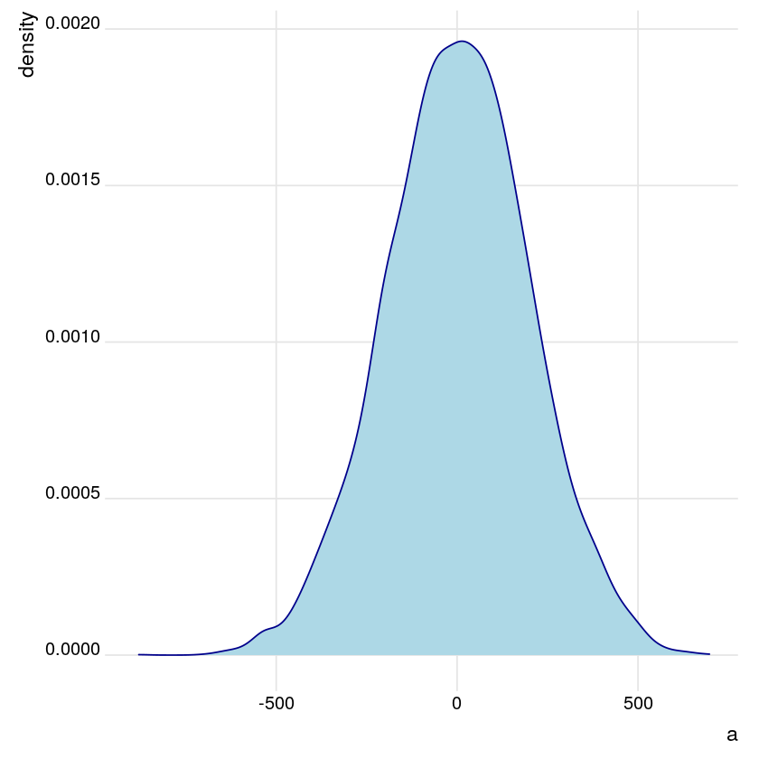

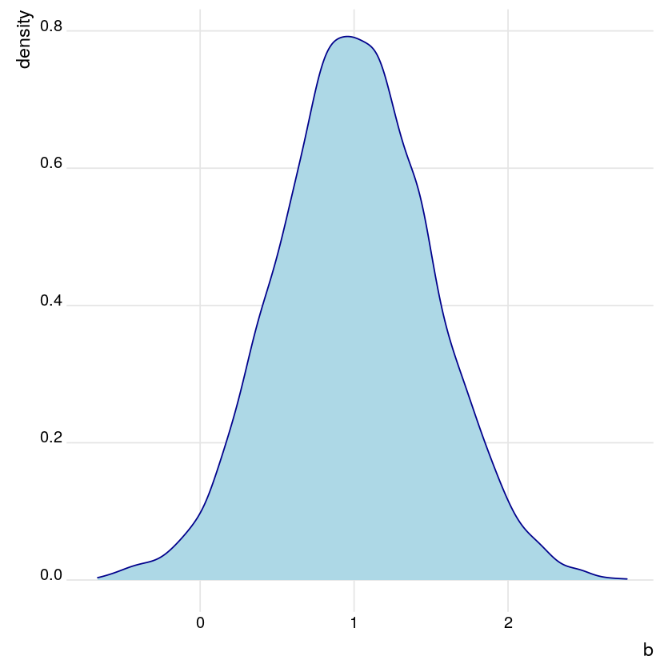

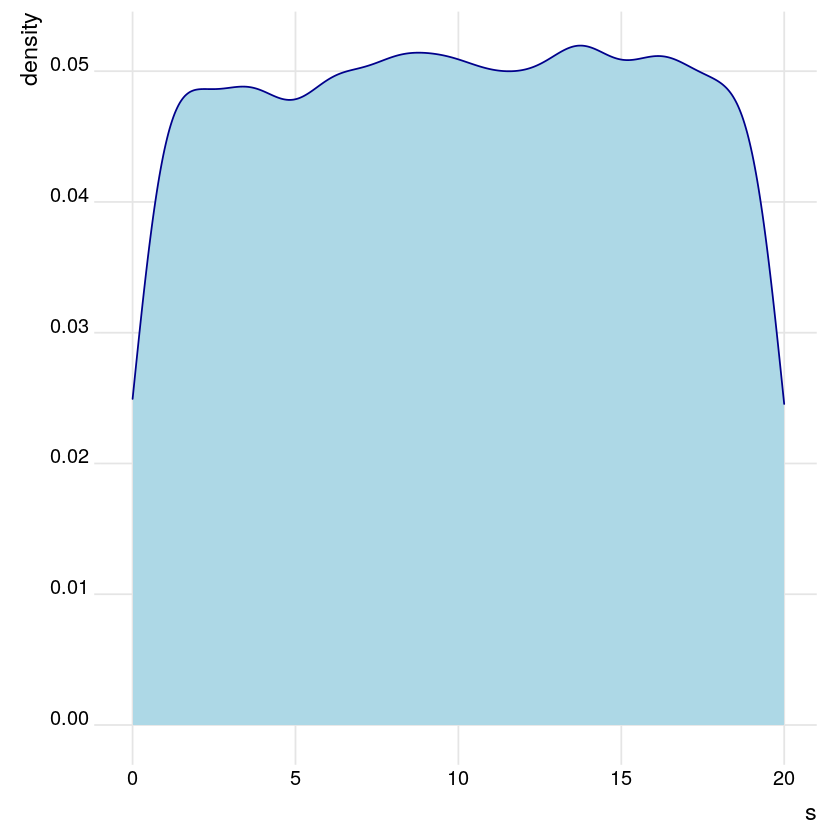

```r
# Take 10000 samples from the a, b, & s priors
a <- rnorm(n = 10000, mean = 0, sd = 200)
b <- rnorm(n = 10000, mean = 1, sd = 0.5)
s <- runif(n = 10000, min = 0, max = 20)

# Store samples in a data frame
samples <- data.frame(set = 1:10000, a, b, s)

# Construct density plots of the prior samples
ggplot(samples, aes(x = a)) +
    geom_density(color='darkblue', fill = 'lightblue') + theme_ridges()
ggplot(samples, aes(x = b)) +
    geom_density(color='darkblue', fill = 'lightblue') + theme_ridges()
ggplot(samples, aes(x = s)) +
    geom_density(color='darkblue', fill = 'lightblue') + theme_ridges()
```

These simulations approximate our prior models of each *separate* model parameter. There's likely a positive association between weight & height ($b > 0$) but more uncertainty about the intercept $a$. Further, at any given height, the typical deviation of individuals' weights from the trend is equally likely to be anywhere between $0$ and $20$ kg.

## Visualizing the regression priors

Previously, we simulated $10,000$ samples for each parameter ($a$, $b$, $s$) in the Bayesian regression model of weight $Y$ by height $X$: $Y \sim N(m,s^2)$ with mean $m = a + bX$. The set of $a$, $b$, and $s$ values in each row of samples represents a prior plausible regression scenario. To explore the scope of these prior scenarios, we will simulate $50$ pairs of height and weight values from **each of the first $12$ sets of prior parameters** $a$, $b$, and $s$.

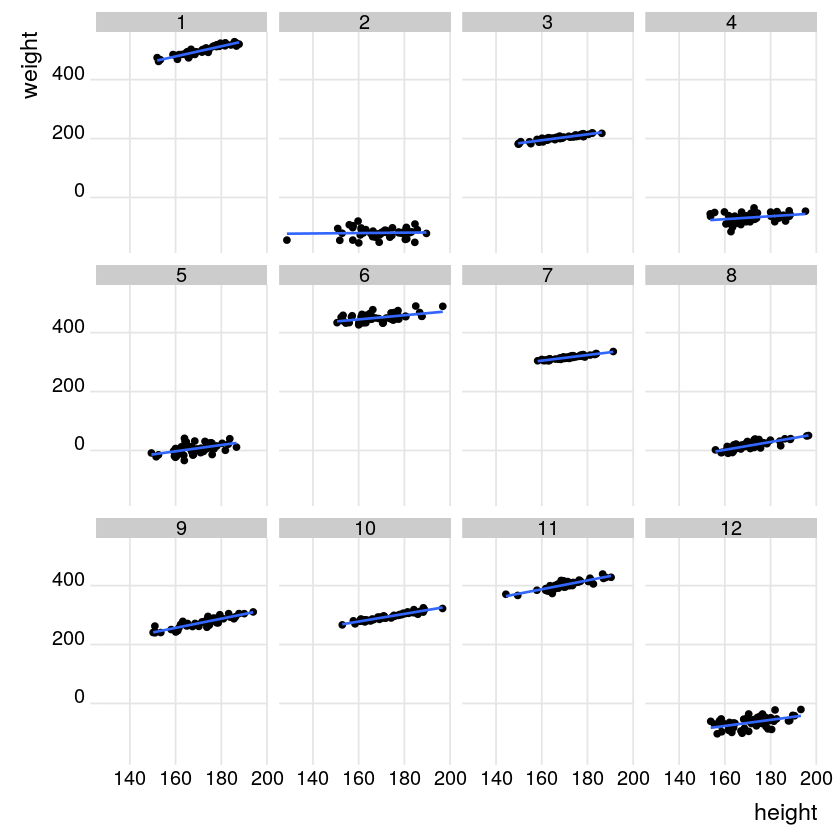

```r
# Replicate the first 12 parameter sets 50 times each
prior_scenarios_rep <- bind_rows(replicate(n = 50, expr = samples[1:12, ], simplify = FALSE))

# Simulate 50 height & weight data points for each parameter set
prior_simulation <- prior_scenarios_rep %>%
    mutate(height = rnorm(n = 600, mean = 170, sd = 10)) %>%
    mutate(weight = rnorm(n = 600, mean = a + b * height, sd = s))

# Plot the simulated data & regression model for each parameter set
ggplot(prior_simulation, aes(x = height, y = weight)) +
    theme_ridges() +
    geom_point() +
    geom_smooth(method = "lm", se = FALSE, size = 0.75) +
    facet_wrap(~ set)
```

These $12$ plots demonstrate the range of prior plausible models. These models have different intercepts, slopes, and residual standard deviations. Almost all of the models have positive slopes, demonstrating the prior information that there is likely a positive association between weight & height. Given our vague prior for $a$, some of these models are even biologically impossible.

# Define, compile, & simulate the regression model

Upon observing the relationship between weight $Y_i$ and height $X_i$ for the $507$ subjects $i$ in the `bdims` data set, we can update our posterior model of this relationship. To build our posterior, we must combine our insights from the likelihood and priors:

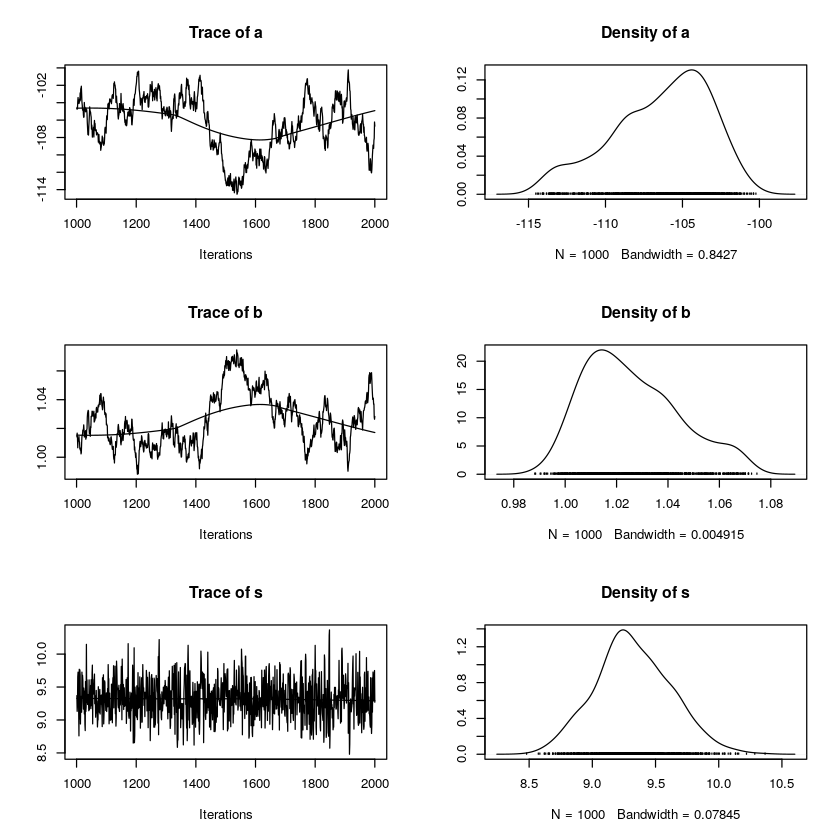

```r
# DEFINE the model
weight_model <- "model{
    # Likelihood model for Y[i]
    for(i in 1:length(Y)) {
    Y[i] ~ dnorm(m[i], s^(-2))
    m[i] <- a + b * X[i]
    }
    # Prior models for a, b, s
    a ~ dnorm(0, 200^(-2))
    b ~ dnorm(1, 0.5^(-2))
    s ~ dunif(0, 20)
    }"

# COMPILE the model
weight_jags <- jags.model(textConnection(weight_model), data = list(Y = bdims$wgt, X = bdims$hgt),
                          inits = list(.RNG.name = "base::Wichmann-Hill", .RNG.seed = 1989))

# SIMULATE the posterior
weight_sim <- coda.samples(model = weight_jags, variable.names = c("a", "b", "s"), n.iter = 1000)

# PLOT the posterior
plot(weight_sim)
```

We've successfully defined, compiled, and simulated your Bayesian regression model. But the results don't look that great. Let's fix that.

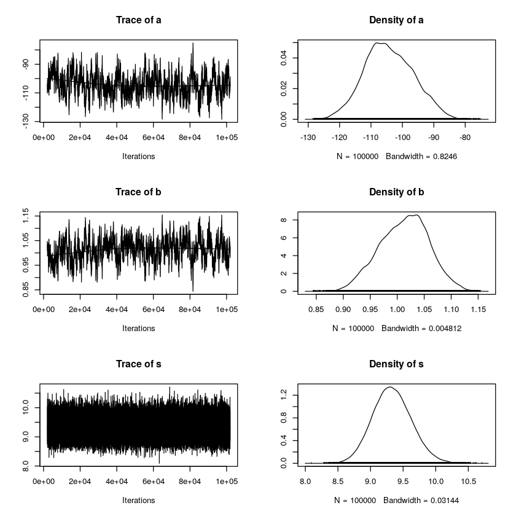

```r
# SIMULATE the posterior 100,000 times
weight_sim <- coda.samples(model = weight_jags, variable.names = c("a", "b", "s"), n.iter = 100000)

# PLOT the posterior
plot(weight_sim)
```

Trace plots indicate that after only $1,000$ iterations, the $a$ and $b$ parallel chains had not stabilized. However, after $100,000$ iterations, the chains demonstrate greater stability. We might also increase the stability of our simulation by *standardizing* the height data.

# Posterior estimation & inference

## Posterior point estimates

Recall the likelihood of the Bayesian regression model of weight $Y$ by height $X$: $Y \sim N(m,s^2)$ where $m = a + bX$. A $100,000$ iteration **RJAGS** simulation of the posterior.

The posterior *means* of the intercept & slope parameters, *a* & *b*, reflect the posterior mean trend in the relationship between weight & height. In contrast, the full posteriors of *a* & *b* reflect the range of plausible parameters, thus posterior uncertainty in the trend. We will examine the trend and uncertainty.

```
Iterations = 2001:102000
Thinning interval = 1
Number of chains = 1
Sample size per chain = 1e+05

1. Empirical mean and standard deviation for each variable,
   plus standard error of the mean:

      Mean      SD  Naive SE Time-series SE
a -104.222 7.77968 0.0246015       0.646878
b    1.013 0.04539 0.0001435       0.003794
s    9.331 0.29656 0.0009378       0.001214

2. Quantiles for each variable:

       2.5%       25%      50%     75%   97.5%
a -118.8879 -109.7096 -104.681 -98.780 -88.712
b    0.9224    0.9813    1.016   1.045   1.098
s    8.7743    9.1273    9.323   9.526   9.938
```

1.01301864233895

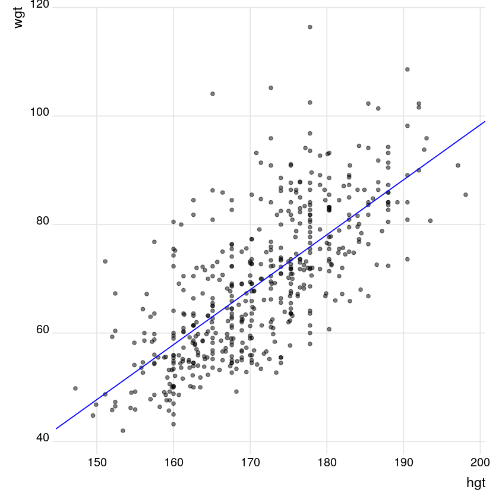

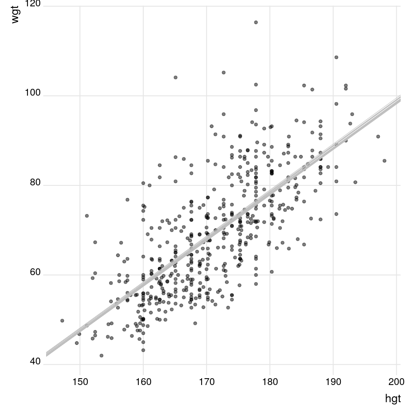

```r
# Summarize the posterior Markov chains
summary(weight_sim)

# Store the chains in a data frame
weight_chains <- data.frame(weight_sim[[1]])

# Calculate the estimated posterior mean of b
mean(weight_chains$b)

# Plot the posterior mean regression model
ggplot(bdims, aes(x = hgt, y = wgt)) +
    geom_point(alpha=0.5) +
    geom_abline(intercept = mean(weight_chains$a), slope = mean(weight_chains$b), color = "blue") +
    theme_ridges()

# Visualize the range of 20 posterior regression models
ggplot(bdims, aes(x = hgt, y = wgt)) +
    geom_point(alpha=0.5) +
    geom_abline(intercept = weight_chains$a[1:20], slope = weight_chains$b[1:20], color = "gray", size = 0.25) +
    theme_ridges()
```

We now have a sense of the posterior mean trend in the linear relationship between weight and height as well as the posterior uncertainty in this trend. Given the size of the data and selection of priors, the posterior uncertainty is noticeably small as evidenced by the tight distribution of the gray posterior plausible lines around the trend.

## Posterior credible intervals

Let's focus on slope parameter $b$, the rate of change in weight over height. The **posterior mean** of $b$ reflects the trend in the posterior model of the slope. In contrast, a posterior **credible interval** provides a range of posterior plausible slope values, thus reflects posterior uncertainty about $b$. For example, the $95\%$ credible interval for $b$ ranges from the $2.5$th to the $97.5$th quantile of the $b$ posterior. Thus there's a $95\%$ (posterior) chance that $b$ is in this range.

We will use **RJAGS** simulation output to approximate credible intervals for $b$. The $100,000$ iteration **RJAGS** simulation of the posterior.

```
Iterations = 2001:102000
Thinning interval = 1
Number of chains = 1
Sample size per chain = 1e+05

1. Empirical mean and standard deviation for each variable,
   plus standard error of the mean:

      Mean      SD  Naive SE Time-series SE
a -104.222 7.77968 0.0246015       0.646878
b    1.013 0.04539 0.0001435       0.003794
s    9.331 0.29656 0.0009378       0.001214

2. Quantiles for each variable:

       2.5%       25%      50%     75%   97.5%
a -118.8879 -109.7096 -104.681 -98.780 -88.712
b    0.9224    0.9813    1.016   1.045   1.098
s    8.7743    9.1273    9.323   9.526   9.938
```

**2.5%**

0.922431069239868

**97.5%**

1.09832721321415

**5%**

0.934841323648004

**95%**

1.0851637941592

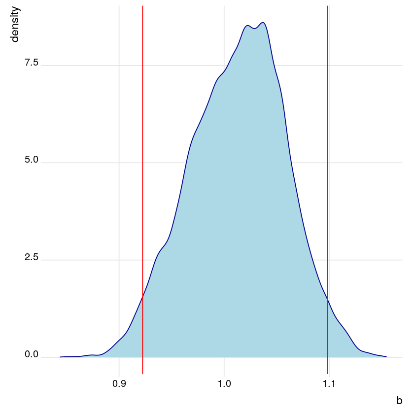

```r
# Summarize the posterior Markov chains
summary(weight_sim)

# Calculate the 95% posterior credible interval for b
ci_95 <- quantile(weight_chains$b, probs = c(0.025, 0.975))
ci_95

# Calculate the 90% posterior credible interval for b
ci_90 <- quantile(weight_chains$b, probs = c(0.05, 0.95))
ci_90

# Mark the 90% credible interval
ggplot(weight_chains, aes(x = b)) +
    geom_density(color='darkblue', fill = 'lightblue') +
    geom_vline(xintercept = ci_95, color = "red") +
    theme_ridges()
```

Based on our calculations we can say that there's a $95\%$ (posterior) probability that, on average, the increase in weight per $1$ cm increase in height is between $0.92$ and $1.1$ kg.

## Posterior probabilities

We've used **RJAGS** output to explore and quantify the posterior trend & uncertainty $b$. We can also use **RJAGS** output to assess specific hypotheses. For example: What's the posterior probability that, on average, weight increases by more than $1.1$ kg for every $1$ cm increase in height? That is, what's the posterior probability that $b > 1.1$?

We will approximate this probability by the proportion of $b$ Markov chain values that exceed $1.1$.

```
FALSE  TRUE
97751  2249
```

0.02249

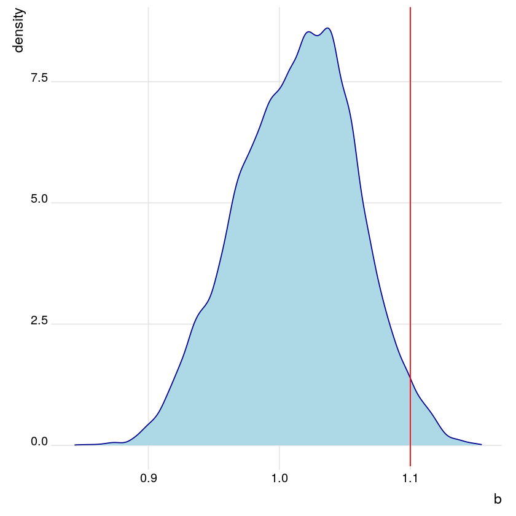

```r
# Mark 1.1 on a posterior density plot for b
ggplot(weight_chains, aes(x = b)) +
    geom_density(color='darkblue', fill = 'lightblue') +
    geom_vline(xintercept = 1.1, color = "red") +
    theme_ridges()

# Summarize the number of b chain values that exceed 1.1
table(weight_chains$b > 1.1)

# Calculate the proportion of b chain values that exceed 1.1
mean(weight_chains$b > 1.1)
```

Based on our calculations we can say that there's only a $\sim 2 \%$ (posterior) chance that, on average, the increase in weight per $1$ cm increase in height exceeds $1.1$ kg.

# Posterior prediction

## Inference for the posterior trend

Recall the likelihood of the Bayesian regression model of weight $Y$ by height $X$: $Y \sim N(m,s^2)$ where $ m = a + bX$. Earlier we approximated the form of the posterior trend $m$ (solid line). From this, notice that the typical weight among 180 cm adults is roughly 80 kg (dashed lines).

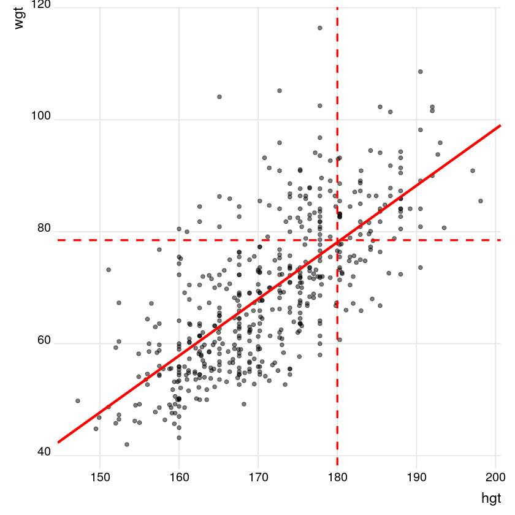

```r
# Plot the posterior mean regression model
ggplot(bdims, aes(x = hgt, y = wgt)) +
    geom_point(alpha=0.5) +
    geom_abline(intercept = mean(weight_chains$a), slope = mean(weight_chains$b), color = "red", size = 1.2) +
    geom_vline(xintercept = 180, color = "red", linetype = "dashed", size = 0.9) +
    geom_hline(yintercept = 78.5, color = "red", linetype = "dashed", size = 0.9) +
    theme_ridges()
```

We will use **RJAGS** simulation output to approximate the posterior *trend* in weight among $180$ cm tall adults as well as the posterior *uncertainty* in this trend.

**2.5%**

76.9779317726052

**97.5%**

79.2381030211462

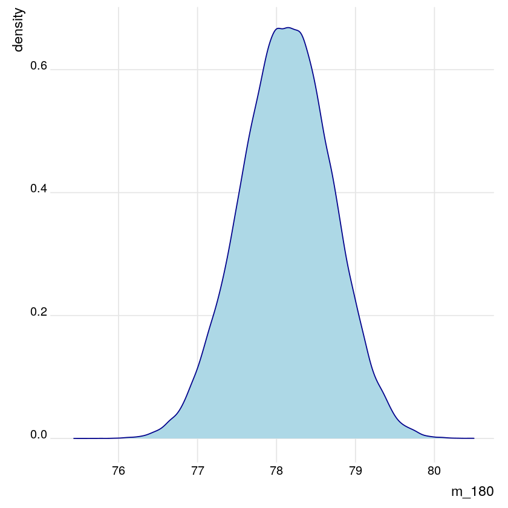

```r
# Calculate the trend under each Markov chain parameter set
weight_chains <- weight_chains  %>%
    mutate(m_180 = a + b * 180)

# Construct a posterior density plot of the trend
ggplot(weight_chains, aes(x = m_180)) +
    geom_density(color='darkblue', fill = 'lightblue') +
    theme_ridges()

# Construct a 95% posterior credible interval for the trend
quantile(weight_chains$m_180, probs = c(0.025, 0.975))
```

The posterior trend of our regression model indicates that the typical weight among $180$ cm tall adults is roughly $78$ kg. However, posterior uncertainty in the regression model trickles down to uncertainty about this trend. This uncertainty is communicated through our credible interval: there's a $95\%$ (posterior) chance that the typical weight at a height of $180$ cm is between $76.98$ and $79.24$ kg.